# Birthday Paradox

Jon Wayland

9/9/2023

*Note: I originally wrote this on Quora in 2019.*

My wife has 9 siblings, and believe it or not, she shares the same birthday as one of her brothers.

When people hear this, they’re shocked because they believe the chances of this happening are slim-to-none. Though probability does favor this *not* happening, the chances are still much greater than most people think.

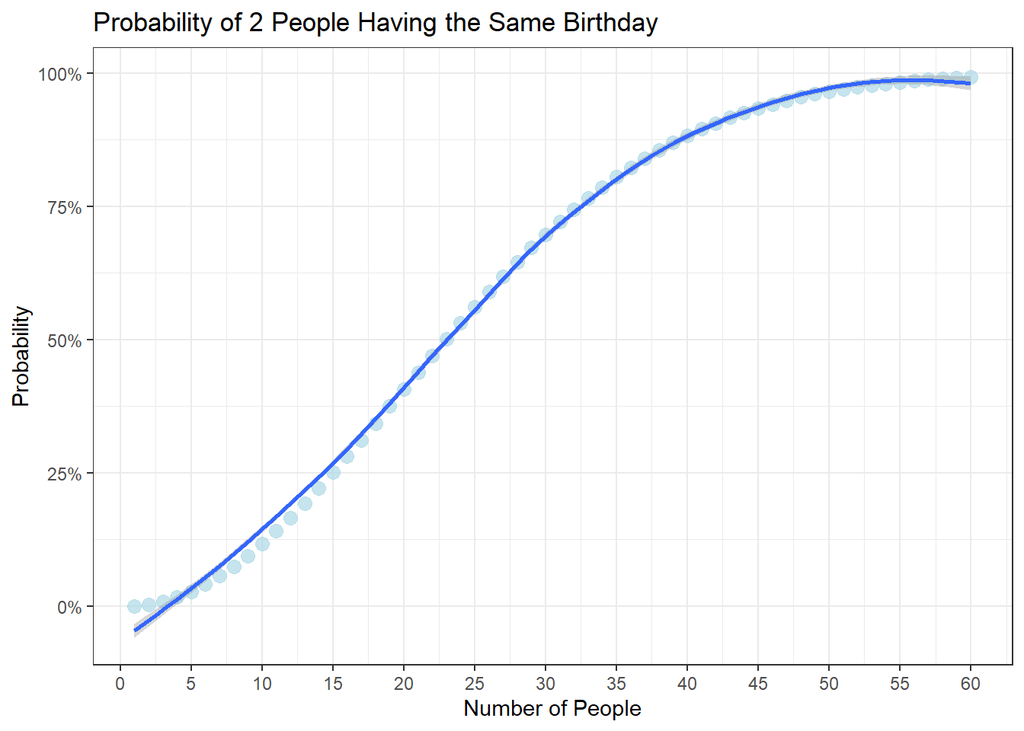

With 10 people, the probability of any two of them having the same birthday is 11.6%. Again, not in favor of happening, but certainly greater than slim-to-none.

## Why is the probability so high?

The “paradox” comes into play because of our perception of the problem. We fixate on a single person, and then assume the likelihood that they alone share the same birthday as someone else.

Instead, we can think of it as every possible pairing of 2 people. For my wife and her 9 siblings, there are 45 possible pairs of 2 people. That’s 45 combinations of 10 distinct birthdays looking for a match.

The distinct pairings of $n$ people can be represented by $\frac{n∗(n−1)}{2}$. For a single pairing, there is a $\frac{1}{365}$ chance that the two people share the same birthday, which we will see why in a moment.

For $k$ pairings, there is a $1−\frac{364}{365}^k$, or $1−\frac{364}{365}^\frac{n∗(n−1)}{2}$ (in terms of $n$ people) chance that any two people share the same birthday.

## Probability Formula

I find it easiest to understand by beginning with the most intuitive case, a single pairing, $n=2$.

Substituting $2$ for $n$, we get $1−\frac{364}{365}^\frac{2∗(2−1)}{2} = 1−\frac{364}{365}^1=\frac{1}{365}$. In other words, the chances of two out of two people having the same birthday are 1 in 365 days. Makes sense.

Now that we trust the formula, let’s break down the probability of any $2$ out of $n$ people having the same birthday: $1−\frac{364}{365}^\frac{n∗(n−1)}{2}$

First, we can remove the “$1−$” from the formula and interpret the remaining portion as the probability of any pair of people **not** having the same birthday. So, we’re left with $\frac{364}{365}^\frac{n∗(n−1)}{2}$.

- $1$ in the $n=2$ case
- $3$ in the $n=3$ case
- $6$ in the $n=4$ case
- $10$ in the $n=5$ case
- $15$ in the $n=6$ case
- $21$ in the $n=7$ case
- $28$ in the $n=8$ case
- $36$ in the $n=9$ case
- $45$ in the $n=10$ case

So with my wife and her $9$ siblings, i.e. the $n=10$ case, the power is $45$. Plug this in to the formula and the probability of any two of them having the same birthday is: $1−\frac{364}{365}^\frac{n∗(n−1)}{2}=1−\frac{364}{365}^{45}=0.1161$

Increase $n$ to $23$ people and the probability that any two people share the same birthday becomes 50–50 (try it out). The probability surpasses 80% with only 35 people.To go full circle, think of it in terms of pairs: with 23 people, we have 253 possible combinations searching for a match. With 35 people, we have 595 possible combinations searching for a match.

Doesn’t sound slim-to-none after all.